# U13_PreLive

Johnny Vogt

2025-11-17

## Discussion 1: PCA Basics Review

For this discussion we will be utilizing a data set that was a study investigating potential civil rights violations among insurance companies operating in Chicago, Illinois. A description of the data set can be found as well as a description for each variable. Please take the time and read through the description before continuing.

```r
library(Sleuth3)
mydata<-ex1716
head(mydata)
```

```
##   ZIP Fire Theft  Age Income Race Vol Invol
## 1  26  6.2    29 60.4  11744 10.0 5.3   0.0
## 2  40  9.5    44 76.5   9323 22.2 3.1   0.1
## 3  13 10.5    36 73.5   9948 19.6 4.8   1.2
## 4  57  7.7    37 66.9  10656 17.3 5.7   0.5
## 5  14  8.6    53 81.4   9730 24.5 5.9   0.7
## 6  10 34.1    68 52.6   8231 54.0 4.0   0.3
```

```r
names(mydata)
```

```
## [1] "ZIP"    "Fire"   "Theft"  "Age"    "Income" "Race"   "Vol"    "Invol"
```

```r
?ex1716
```

```
## starting httpd help server ... done
```

For this exercise we will be treating the `Vol` variable as the response because it indicates the number of new policies provided per 100 housing units. These new policies were argued to be favorable to certain locations within Chicago and these policies were not offered to others. The age, income, race, theft, and fire variables will be considered as potential predictors of the voluntary new policies awarded by insurance companies. We will ignore the `Invol` variable.

In a regression or classification setting, PCA would be applied to the predictors to help lower the number of predictors to use. Lets run through a few computations and answer some basic questions about our understanding of PCA

### A. First off lets observe basic summary statistics of the predictor variables. Make note of anything interesting. Additionally, create a scatter plot and correlation matrix of the five predictor variables.

```r
library(dplyr)
library(tidyr)



mysummary <- mydata %>%
  select(Fire, Theft, Age, Income,Race) %>% # select variables to summarise
  summarise_each(funs(min = min,
                      q25 = quantile(., 0.25),
                      median = median,
                      q75 = quantile(., 0.75),
                      max = max,
                      mean = mean,
                      sd = sd,
                      variance= var))
# reshape it using tidyr functions

clean.summary <- mysummary %>% gather(stat, val) %>%
  separate(stat, into = c("var", "stat"), sep = "_") %>%
  spread(stat, val) %>%
  select(var, min, max, mean, sd,variance) # reorder columns
print(clean.summary)
```

```
##      var  min     max        mean          sd     variance
## 1    Age    2    90.1    60.32766   22.574964 5.096290e+02
## 2   Fire    2    39.7    12.27872    9.302266 8.653215e+01
## 3 Income 5583 21480.0 10695.82979 2754.198008 7.585607e+06
## 4   Race    1    99.7    34.98511   32.587614 1.061953e+03
## 5  Theft    3    75.0    30.23404   14.533638 2.112266e+02
```

```r
preds <- mydata[, c("Age", "Income", "Race", "Theft", "Fire")]

library(GGally)
```

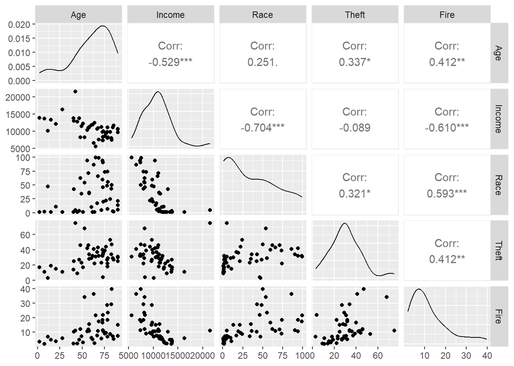

```r
ggpairs(preds)
```

```r
cor_mat <- cor(preds)
print(cor_mat)
```

```
##               Age      Income       Race       Theft       Fire
## Age     1.0000000 -0.52866953  0.2505118  0.33694341  0.4122225
## Income -0.5286695  1.00000000 -0.7037328 -0.08943088 -0.6104481
## Race    0.2505118 -0.70373285  1.0000000  0.32136909  0.5927956
## Theft   0.3369434 -0.08943088  0.3213691  1.00000000  0.4121614
## Fire    0.4122225 -0.61044807  0.5927956  0.41216143  1.0000000
```

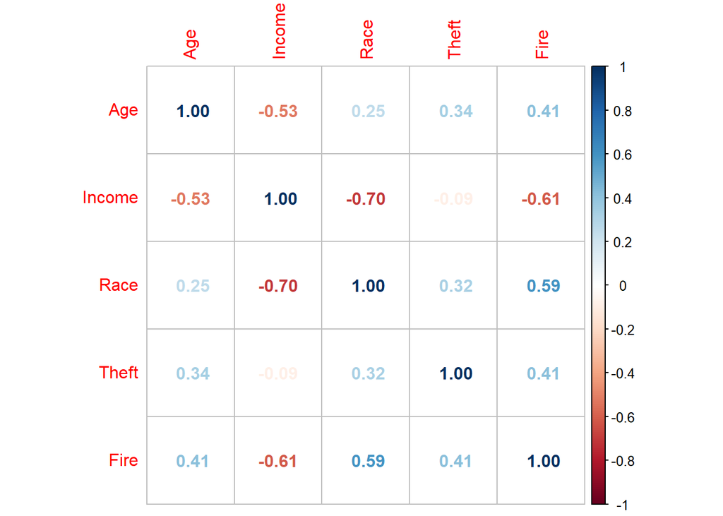

```r
library(corrplot)
corrplot(cor_mat, method = "number")
```

### B.The following code produces three key results. The eigenvectors, eigenvalues, and a scree plot from a PCA analysis that uses the covariance matrix rather than the correlation matrix. Note this is not typically what is done. What is the scree plot telling us here? Comment on the “weirdness” of the eigen vector for the first PC. Any thoughts on why this occurred?

The scree plot shows us the eignvalues for each principal component. Most of the variance is captured in the first PC, and you cna see this in from the first PC having a very large eignenvalue compared to the other PCs. Scaling was not adjusted for this, so the first Principal component tried to capture all the variance.

```r
pc.result<-prcomp(mydata[,2:6],scale.=FALSE)

#Eigen Vectors
pc.result$rotation
```

```
##                  PC1          PC2         PC3          PC4          PC5
## Fire    0.0020617673 -0.097740929 0.123122260 -0.209894627  0.965001355
## Theft   0.0004721111 -0.243966789 0.485518217 -0.798134174 -0.260257343
## Age     0.0043331964  0.252841469 0.860436215  0.442219199  0.012004758
## Income -0.9999537066 -0.006974434 0.004990079  0.004031319  0.001670201
## Race    0.0083267254 -0.931101211 0.093475068  0.351215055 -0.029859620
```

```r
#Eigen Values
eigenvals<-pc.result$sdev^2
eigenvals
```

```
## [1] 7.586309e+06 5.975363e+02 4.137852e+02 1.157325e+02 3.995145e+01
```

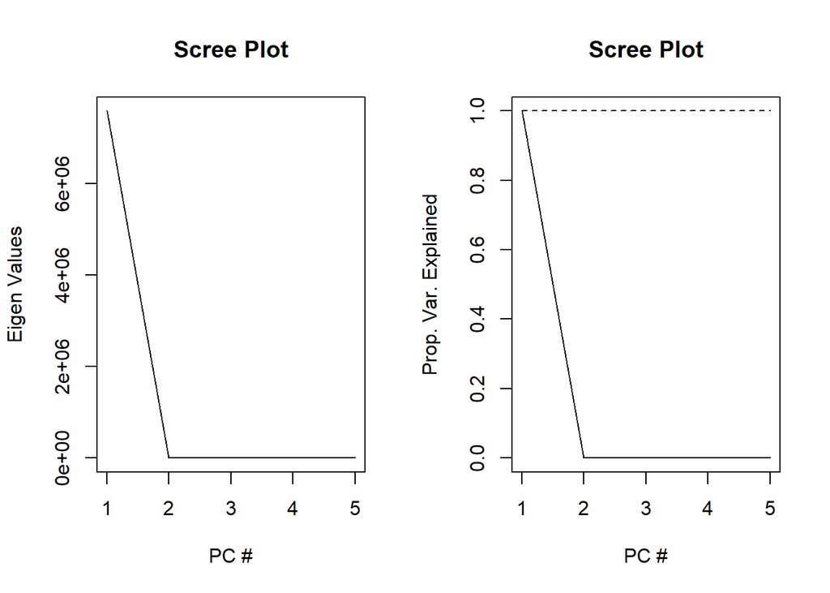

```r
#Scree plot
par(mfrow=c(1,2))
plot(eigenvals,type="l",main="Scree Plot",ylab="Eigen Values",xlab="PC #")
plot(eigenvals/sum(eigenvals),type="l",main="Scree Plot",ylab="Prop. Var. Explained",xlab="PC #",ylim=c(0,1))
cumulative.prop<-cumsum(eigenvals/sum(eigenvals))
lines(cumulative.prop,lty=2)
```

### C. We can extract the new variables created from PCA by using the following command. I am going to append the response variable to the data set for future work.

```r
pc.scores<-pc.result$x
pc.scores<-data.frame(pc.scores,Vol=ex1716$Vol)

summary(pc.scores)
```

```
##       PC1                  PC2               PC3               PC4
##  Min.   :-10783.980   Min.   :-62.480   Min.   :-57.884   Min.   :-41.398
##  1st Qu.: -1293.453   1st Qu.:-15.739   1st Qu.:-10.609   1st Qu.: -6.297
##  Median :     1.702   Median :  2.528   Median :  3.194   Median :  2.769
##  Mean   :     0.000   Mean   :  0.000   Mean   :  0.000   Mean   :  0.000
##  3rd Qu.:  2248.995   3rd Qu.: 20.495   3rd Qu.: 11.321   3rd Qu.:  7.280
##  Max.   :  5113.172   Max.   : 35.480   Max.   : 57.325   Max.   : 18.989
##       PC5               Vol
##  Min.   :-10.522   Min.   : 0.500
##  1st Qu.: -3.582   1st Qu.: 3.100
##  Median : -1.620   Median : 5.900
##  Mean   :  0.000   Mean   : 6.743
##  3rd Qu.:  2.967   3rd Qu.:10.450
##  Max.   : 16.510   Max.   :17.900
```

```r
sapply(pc.scores[, 1:5], var)
```

```
##          PC1          PC2          PC3          PC4          PC5
## 7.586309e+06 5.975363e+02 4.137852e+02 1.157325e+02 3.995145e+01
```

Use this new data set and compute the same summary statistics on these new variables. Examine the variance’s for these new variables. Do they look familiar?’

They do look familiar, theyre the same from above

4. Create a scatterplot matrix for these new variables to visualize that they are uncorrelated

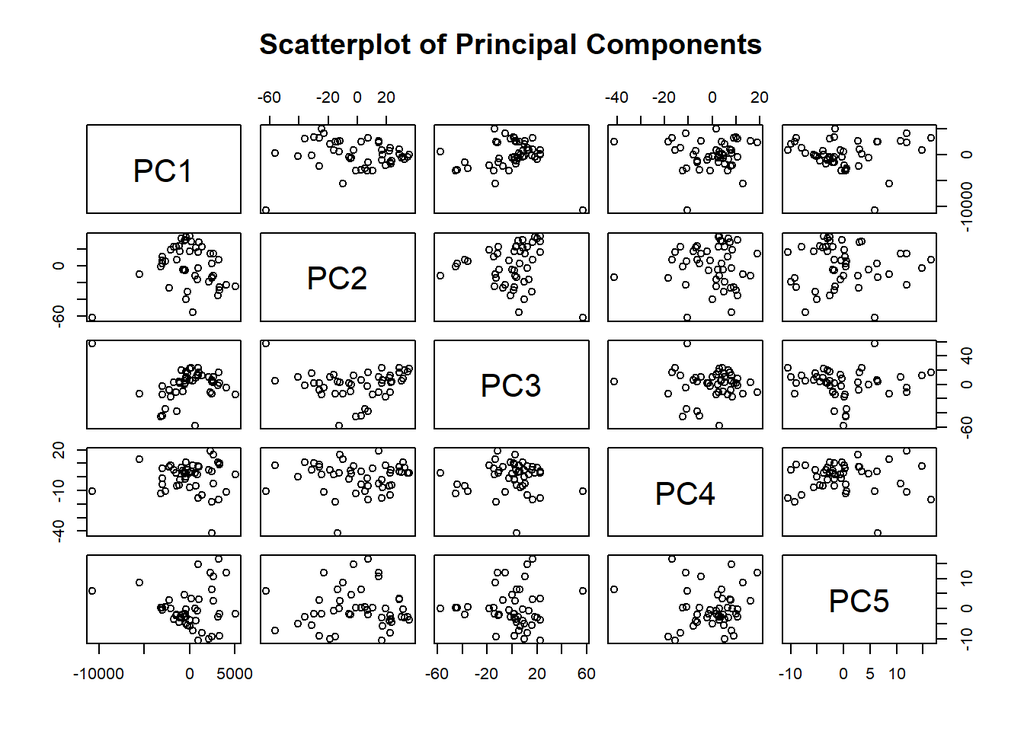

```r
pairs(pc.scores[, 1:5], main = "Scatterplot of Principal Components")
```

5. Run the PCA analysis again this time setting the scale option to true. Compare the eigenvectors, eigenvalues, and scree plot from the first run. How does the interpretation of the first principle component change?

```r
pc.result.scaled <- prcomp(mydata[,2:6], scale. = TRUE)
# Eigenvectors
pc.result.scaled$rotation
```

```
##               PC1         PC2        PC3        PC4        PC5
## Fire    0.5048229 -0.03090255  0.1890711 -0.8296296  0.1420061
## Theft   0.3090776 -0.83261158  0.2407813  0.2183405 -0.3249320
## Age     0.3985347 -0.19233538 -0.8163274  0.1235444  0.3500337
## Income -0.5050429 -0.45724546  0.1426136 -0.1371460  0.7047769
## Race    0.4855169  0.24441088  0.4685589  0.4795518  0.5049944
```

```r
# Eigenvalues
eigenvals.scaled <- pc.result.scaled$sdev^2
eigenvals.scaled
```

```
## [1] 2.7586160 0.9496824 0.7537101 0.3865744 0.1514171
```

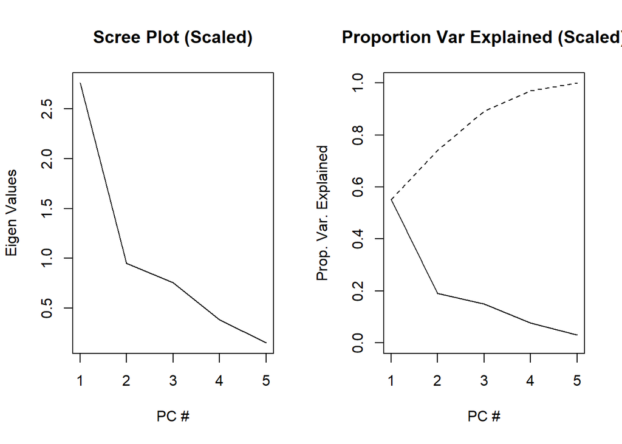

```r
# Scree plot
par(mfrow = c(1,2))
plot(eigenvals.scaled, type = "l", main = "Scree Plot (Scaled)", ylab = "Eigen Values", xlab = "PC #")
plot(eigenvals.scaled / sum(eigenvals.scaled), type = "l", main = "Proportion Var Explained (Scaled)", ylab = "Prop. Var. Explained", xlab = "PC #", ylim = c(0, 1))
lines(cumsum(eigenvals.scaled / sum(eigenvals.scaled)), lty = 2)
```

During the live session, we will investigate a regression model using the original variables and a regression model using the PCs to further the discussion.

After scaling, PC1 acts closer to a weighted average of all the predictors rather than the LARGEST variation.

## Discussion 2: Image Compression

This following bulleted list of commands will demonstrate the image compression example discussed in the videos. There is really nothing due for this section. It is just for curious students.

1. Load in the packages to read in a JPEG file. It also contains a function to write objects back to JPEG. Note that the object is just an array with three matrices: one each for red, green, and blue channels. Each matrix is 516 rows by 470 columns.

```r
library(jpeg)
library(magick)
#setwd()
photo<-readJPEG("Luna.jpg")
dim(photo)
```

```
## [1] 516 470   3
```

```r
attributes(photo)
```

```
## $dim
## [1] 516 470   3
```

2. The next step is to perform data reduction using PCA.

```r
pcaR<-prcomp(photo[,,1],scale.=T)
pcaG<-prcomp(photo[,,2],scale.=T)
pcaB<-prcomp(photo[,,3],scale.=T)
```

3. Load in the function Dr. Turner provided that does the matrix multiplication to go from PCs back to the original variables scale.

```r
#Function here always assumes you are centering and scaling variables
pc.approx<-function(pcres,num){
  n<-nrow(pcres$x)
  #X.approx<-(pcres$x[,1:num]%*%t(pcres$rotation[,1:num])+rep(pcres$center,each=n))/rep(pcres$scale,each=n)
  X.approx<-rep(pcres$scale,each=n)*(pcres$x[,1:num]%*%t(pcres$rotation[,1:num]))+rep(pcres$center,each=n)
  names(X.approx)<-names(pcres$center)
  X.approx
}
```

4. Store the PCA results in a list, and apply the transformation function using just 20 PCs. Image is then written to your working directory. You can change the number of PCs to see how the image changes.

```r
pcaRGB<-list(pcaR,pcaG,pcaB)

compImage<-sapply(pcaRGB,pc.approx,num=20,simplify='array')

#setwd("~/Desktop/CourseDev/Unit 13/PreLive")
writeJPEG(compImage,"Luna_PC20.jpg")
#File will be much smaller than original
```

it went from 69kb to 22kb!!!